# Airfare_Price_Prediction

## Airfare Price Prediction

Statement of Issue It can be hard to guess airline ticket rates, we might see a fare today, find out the price of the same flight tomorrow, it's going to be a different story. We may have heard travelers sometimes complain that the costs of airline fares are too volatile. As data scientists, we can show that something can be expected provided the correct data.

FEATURES: Airline: The name of the airline.

Date_of_Journey: The date of the journey

Source: The source from which the service begins.

Destination: The destination where the service ends.

Route: The route taken by the flight to reach the destination.

Dep_Time: The time when the journey starts from the source.

Arrival_Time: Time of arrival at the destination.

Duration: Total duration of the flight.

Total_Stops: Total stops between the source and destination.

Additional_Info: Additional information about the flight

Price: The price of the ticket

```python
import pandas as pd
import numpy as np
import matplotlib.pyplot as plt
%matplotlib inline
import seaborn as sns
sns.set()
import warnings
warnings.filterwarnings('ignore')
pd.set_option('display.max_columns', None)
```

# Importing dataset

```python
df=pd.read_excel('Python_Flight_Fare_d.xlsx')
df.head()
```

|  | Airline | Date_of_Journey | Source | Destination | Route | Dep_Time | Arrival_Time | Duration | Total_Stops | Additional_Info | Price |
| --- | --- | --- | --- | --- | --- | --- | --- | --- | --- | --- | --- |
| 0 | IndiGo | 24/03/2019 | Banglore | New Delhi | BLR → DEL | 22:20 | 01:10 22 Mar | 2h 50m | non-stop | No info | 3897 |
| 1 | Air India | 1/05/2019 | Kolkata | Banglore | CCU → IXR → BBI → BLR | 05:50 | 13:15 | 7h 25m | 2 stops | No info | 7662 |
| 2 | Jet Airways | 9/06/2019 | Delhi | Cochin | DEL → LKO → BOM → COK | 09:25 | 04:25 10 Jun | 19h | 2 stops | No info | 13882 |
| 3 | IndiGo | 12/05/2019 | Kolkata | Banglore | CCU → NAG → BLR | 18:05 | 23:30 | 5h 25m | 1 stop | No info | 6218 |
| 4 | IndiGo | 01/03/2019 | Banglore | New Delhi | BLR → NAG → DEL | 16:50 | 21:35 | 4h 45m | 1 stop | No info | 13302 |

# Chech basic information of dataset

```python
df.info()
```

```
<class 'pandas.core.frame.DataFrame'>
RangeIndex: 10683 entries, 0 to 10682
Data columns (total 11 columns):
 #   Column           Non-Null Count  Dtype
---  ------           --------------  -----
 0   Airline          10683 non-null  object
 1   Date_of_Journey  10683 non-null  object
 2   Source           10683 non-null  object
 3   Destination      10683 non-null  object
 4   Route            10682 non-null  object
 5   Dep_Time         10683 non-null  object
 6   Arrival_Time     10683 non-null  object
 7   Duration         10683 non-null  object
 8   Total_Stops      10682 non-null  object
 9   Additional_Info  10683 non-null  object
 10  Price            10683 non-null  int64
dtypes: int64(1), object(10)
memory usage: 918.2+ KB
```

# check the count of null values in dataset column

```python
df.isna().sum()
```

```
Airline            0
Date_of_Journey    0
Source             0
Destination        0
Route              1
Dep_Time           0
Arrival_Time       0
Duration           0
Total_Stops        1
Additional_Info    0
Price              0
dtype: int64
```

### Drop all Null value

```python
df.dropna(inplace=True)
```

```python
df.shape
```

```
(10682, 11)
```

## Now we extract day values and month values from Date_of_Journey and create two new columns Day_0f_Journey & Month_of_Journey and delet Date_of_Journey

```python
df['Day_of_Journey']=pd.to_datetime(df['Date_of_Journey'], format='%d/%m/%Y').dt.day
df['Month_of_Journey']=pd.to_datetime(df['Date_of_Journey'], format='%d/%m/%Y').dt.month
df.drop('Date_of_Journey', axis=1, inplace=True)

df.head()
```

|  | Airline | Source | Destination | Route | Dep_Time | Arrival_Time | Duration | Total_Stops | Additional_Info | Price | Day_of_Journey | Month_of_Journey |
| --- | --- | --- | --- | --- | --- | --- | --- | --- | --- | --- | --- | --- |
| 0 | IndiGo | Banglore | New Delhi | BLR → DEL | 22:20 | 01:10 22 Mar | 2h 50m | non-stop | No info | 3897 | 24 | 3 |
| 1 | Air India | Kolkata | Banglore | CCU → IXR → BBI → BLR | 05:50 | 13:15 | 7h 25m | 2 stops | No info | 7662 | 1 | 5 |
| 2 | Jet Airways | Delhi | Cochin | DEL → LKO → BOM → COK | 09:25 | 04:25 10 Jun | 19h | 2 stops | No info | 13882 | 9 | 6 |
| 3 | IndiGo | Kolkata | Banglore | CCU → NAG → BLR | 18:05 | 23:30 | 5h 25m | 1 stop | No info | 6218 | 12 | 5 |
| 4 | IndiGo | Banglore | New Delhi | BLR → NAG → DEL | 16:50 | 21:35 | 4h 45m | 1 stop | No info | 13302 | 1 | 3 |

# same things we have do with Dep_time column , we create two new column Dep_hour and Dep_min from extract hour and min from Dep_Time

```python
df['dep_hour']=pd.to_datetime(df['Dep_Time']).dt.hour
df['dep_min']=pd.to_datetime(df['Dep_Time']).dt.minute
df.drop('Dep_Time', axis=1, inplace=True)

df.head()
```

|  | Airline | Source | Destination | Route | Arrival_Time | Duration | Total_Stops | Additional_Info | Price | Day_of_Journey | Month_of_Journey | dep_hour | dep_min |
| --- | --- | --- | --- | --- | --- | --- | --- | --- | --- | --- | --- | --- | --- |
| 0 | IndiGo | Banglore | New Delhi | BLR → DEL | 01:10 22 Mar | 2h 50m | non-stop | No info | 3897 | 24 | 3 | 22 | 20 |
| 1 | Air India | Kolkata | Banglore | CCU → IXR → BBI → BLR | 13:15 | 7h 25m | 2 stops | No info | 7662 | 1 | 5 | 5 | 50 |
| 2 | Jet Airways | Delhi | Cochin | DEL → LKO → BOM → COK | 04:25 10 Jun | 19h | 2 stops | No info | 13882 | 9 | 6 | 9 | 25 |
| 3 | IndiGo | Kolkata | Banglore | CCU → NAG → BLR | 23:30 | 5h 25m | 1 stop | No info | 6218 | 12 | 5 | 18 | 5 |
| 4 | IndiGo | Banglore | New Delhi | BLR → NAG → DEL | 21:35 | 4h 45m | 1 stop | No info | 13302 | 1 | 3 | 16 | 50 |

## Similar to Dep_time we can extract values from Arrival_Time

```python
df['Arri_hour']=pd.to_datetime(df['Arrival_Time']).dt.hour
df['Arri_min']=pd.to_datetime(df['Arrival_Time']).dt.minute
df.drop('Arrival_Time', axis=1, inplace=True)
df.head()
```

|  | Airline | Source | Destination | Route | Duration | Total_Stops | Additional_Info | Price | Day_of_Journey | Month_of_Journey | dep_hour | dep_min | Arri_hour | Arri_min |
| --- | --- | --- | --- | --- | --- | --- | --- | --- | --- | --- | --- | --- | --- | --- |
| 0 | IndiGo | Banglore | New Delhi | BLR → DEL | 2h 50m | non-stop | No info | 3897 | 24 | 3 | 22 | 20 | 1 | 10 |
| 1 | Air India | Kolkata | Banglore | CCU → IXR → BBI → BLR | 7h 25m | 2 stops | No info | 7662 | 1 | 5 | 5 | 50 | 13 | 15 |
| 2 | Jet Airways | Delhi | Cochin | DEL → LKO → BOM → COK | 19h | 2 stops | No info | 13882 | 9 | 6 | 9 | 25 | 4 | 25 |
| 3 | IndiGo | Kolkata | Banglore | CCU → NAG → BLR | 5h 25m | 1 stop | No info | 6218 | 12 | 5 | 18 | 5 | 23 | 30 |
| 4 | IndiGo | Banglore | New Delhi | BLR → NAG → DEL | 4h 45m | 1 stop | No info | 13302 | 1 | 3 | 16 | 50 | 21 | 35 |

## check the all the values in Duration

```python
Duration=list(df.Duration)
Duration
```

```
['2h 50m',
 '7h 25m',
 '19h',
 '5h 25m',
 '4h 45m',
 '2h 25m',
 '15h 30m',
 '21h 5m',
 '25h 30m',
 '7h 50m',
 '13h 15m',
 '2h 35m',
 '2h 15m',
 '12h 10m',
 '2h 35m',
 '26h 35m',
 '4h 30m',
 '22h 35m',
 '23h',
 '20h 35m',
 '5h 10m',
 '15h 20m',
 '2h 50m',
 '2h 55m',
 '13h 20m',
 '15h 10m',
 '5h 45m',
 '5h 55m',
 '2h 50m',
 '2h 15m',
 '2h 15m',
 '13h 25m',
 '2h 50m',
 '22h',
 '5h 30m',
 '10h 25m',
 '5h 15m',
 '2h 30m',
 '6h 15m',
 '11h 55m',
```

[output cut: 946 more lines]

```
 '2h 15m',
 '21h 35m',
 '9h 30m',
 '8h 40m',
 '10h 25m',
 '35h 5m',
 '14h 15m',
 '3h',
 '25h 50m',
 '2h 30m',
 '8h 40m',
 '10h',
 '11h 30m',
 '7h 30m',
 ...]
```

## now create loop for check duration contains only hour min and if yes add min or hour in it

```python
for i in range(len(Duration)):
    if len(Duration[i].split())!=2:
        if 'h' in Duration[i]:
            Duration[i]=Duration[i].strip() + ' 0m'
        else :
            Duration[i]='0h ' + Duration[i]
```

```python
Duration
```

```
['2h 50m',
 '7h 25m',
 '19h 0m',
 '5h 25m',
 '4h 45m',
 '2h 25m',
 '15h 30m',
 '21h 5m',
 '25h 30m',
 '7h 50m',
 '13h 15m',
 '2h 35m',
 '2h 15m',
 '12h 10m',
 '2h 35m',
 '26h 35m',
 '4h 30m',
 '22h 35m',
 '23h 0m',
 '20h 35m',
 '5h 10m',
 '15h 20m',
 '2h 50m',
 '2h 55m',
 '13h 20m',
 '15h 10m',
 '5h 45m',
 '5h 55m',
 '2h 50m',
 '2h 15m',
 '2h 15m',
 '13h 25m',
 '2h 50m',
 '22h 0m',
 '5h 30m',
 '10h 25m',
 '5h 15m',
 '2h 30m',
 '6h 15m',
 '11h 55m',
```

[output cut: 946 more lines]

```
 '2h 15m',
 '21h 35m',
 '9h 30m',
 '8h 40m',
 '10h 25m',
 '35h 5m',
 '14h 15m',
 '3h 0m',
 '25h 50m',
 '2h 30m',
 '8h 40m',
 '10h 0m',
 '11h 30m',
 '7h 30m',
 ...]
```

## now Extract hour and min from duration column and create two new column Dur_hours & Dur_min

```python
Duration=pd.DataFrame(Duration)
Duration
```

|  | 0 |
| --- | --- |
| 0 | 2h 50m |
| 1 | 7h 25m |
| 2 | 19h 0m |
| 3 | 5h 25m |
| 4 | 4h 45m |
| ... | ... |
| 10677 | 2h 30m |
| 10678 | 2h 35m |
| 10679 | 3h 0m |
| 10680 | 2h 40m |
| 10681 | 8h 20m |

10682 rows × 1 columns

```python
df_dur=Duration[0].str.split(expand=True)
df_dur
```

|  | 0 | 1 |
| --- | --- | --- |
| 0 | 2h | 50m |
| 1 | 7h | 25m |
| 2 | 19h | 0m |
| 3 | 5h | 25m |
| 4 | 4h | 45m |
| ... | ... | ... |
| 10677 | 2h | 30m |
| 10678 | 2h | 35m |
| 10679 | 3h | 0m |
| 10680 | 2h | 40m |
| 10681 | 8h | 20m |

10682 rows × 2 columns

```python
df_dur=df_dur.replace({'h':'','m':''}, regex=True)
df_dur
```

|  | 0 | 1 |
| --- | --- | --- |
| 0 | 2 | 50 |
| 1 | 7 | 25 |
| 2 | 19 | 0 |
| 3 | 5 | 25 |
| 4 | 4 | 45 |
| ... | ... | ... |
| 10677 | 2 | 30 |
| 10678 | 2 | 35 |
| 10679 | 3 | 0 |
| 10680 | 2 | 40 |
| 10681 | 8 | 20 |

10682 rows × 2 columns

```python
df_dur.columns=['Dur_hours','Dur_min']
df_dur
```

|  | Dur_hours | Dur_min |
| --- | --- | --- |
| 0 | 2 | 50 |
| 1 | 7 | 25 |
| 2 | 19 | 0 |
| 3 | 5 | 25 |
| 4 | 4 | 45 |
| ... | ... | ... |
| 10677 | 2 | 30 |
| 10678 | 2 | 35 |
| 10679 | 3 | 0 |
| 10680 | 2 | 40 |
| 10681 | 8 | 20 |

10682 rows × 2 columns

## Now drop Duration column

```python
df.drop('Duration',axis=1,inplace=True)
```

## Handling Categorical Data

### check the value counts in Airline

```python
df["Airline"].value_counts()
```

```
Jet Airways                          3849
IndiGo                               2053
Air India                            1751
Multiple carriers                    1196
SpiceJet                              818
Vistara                               479
Air Asia                              319
GoAir                                 194
Multiple carriers Premium economy      13
Jet Airways Business                    6
Vistara Premium economy                 3
Trujet                                  1
Name: Airline, dtype: int64
```

### Display price according to Airline

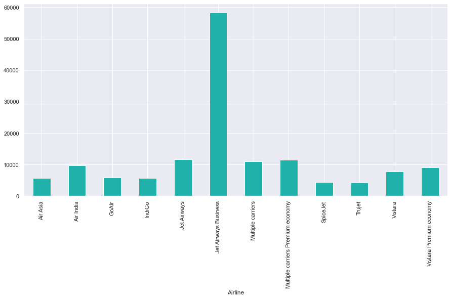

```python
df.groupby('Airline')['Price'].mean().plot(kind='bar',figsize=(15,7), color='lightseagreen')
```

### here we can say that jet airways price higher than any onther airline

## chech the average price according to Airline

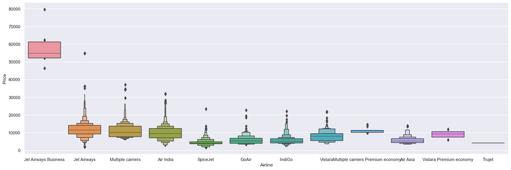

```python
sns.catplot(y = "Price", x = "Airline", data = df.sort_values("Price", ascending = False), kind="boxen", height = 6, aspect = 3)
plt.show()
```

## now we hace to create dummy data for Categorical

### Airline is Nominal Categorical data we will perform OneHotEncoding

```python
Airline=df['Airline']
Airline=pd.get_dummies(Airline)
Airline.head()
```

|  | Air Asia | Air India | GoAir | IndiGo | Jet Airways | Jet Airways Business | Multiple carriers | Multiple carriers Premium economy | SpiceJet | Trujet | Vistara | Vistara Premium economy |
| --- | --- | --- | --- | --- | --- | --- | --- | --- | --- | --- | --- | --- |
| 0 | 0 | 0 | 0 | 1 | 0 | 0 | 0 | 0 | 0 | 0 | 0 | 0 |
| 1 | 0 | 1 | 0 | 0 | 0 | 0 | 0 | 0 | 0 | 0 | 0 | 0 |
| 2 | 0 | 0 | 0 | 0 | 1 | 0 | 0 | 0 | 0 | 0 | 0 | 0 |
| 3 | 0 | 0 | 0 | 1 | 0 | 0 | 0 | 0 | 0 | 0 | 0 | 0 |
| 4 | 0 | 0 | 0 | 1 | 0 | 0 | 0 | 0 | 0 | 0 | 0 | 0 |

## check the Source values counts

```python
df["Source"].value_counts()
```

```
Delhi       4536
Kolkata     2871
Banglore    2197
Mumbai       697
Chennai      381
Name: Source, dtype: int64
```

### display average price according to source

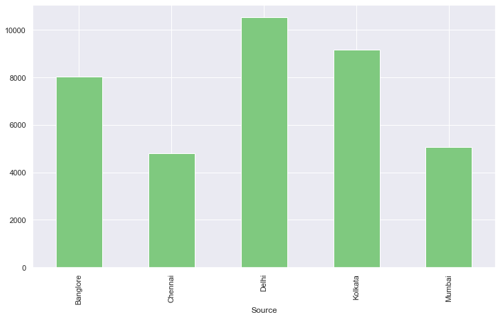

```python
df.groupby('Source')['Price'].mean().plot(kind='bar',figsize=(12,7), cmap='Accent')
```

### here we can say that Delhi Source highest price

### Source is Nominal Categorical data we will perform OneHotEncoding

```python
Source=df[['Source']]

Source=pd.get_dummies(Source)
Source.head()
```

|  | Source_Banglore | Source_Chennai | Source_Delhi | Source_Kolkata | Source_Mumbai |
| --- | --- | --- | --- | --- | --- |
| 0 | 1 | 0 | 0 | 0 | 0 |
| 1 | 0 | 0 | 0 | 1 | 0 |
| 2 | 0 | 0 | 1 | 0 | 0 |
| 3 | 0 | 0 | 0 | 1 | 0 |
| 4 | 1 | 0 | 0 | 0 | 0 |

## check Destination value counts

```python
df["Destination"].value_counts()
```

```
Cochin       4536
Banglore     2871
Delhi        1265
New Delhi     932
Hyderabad     697
Kolkata       381
Name: Destination, dtype: int64
```

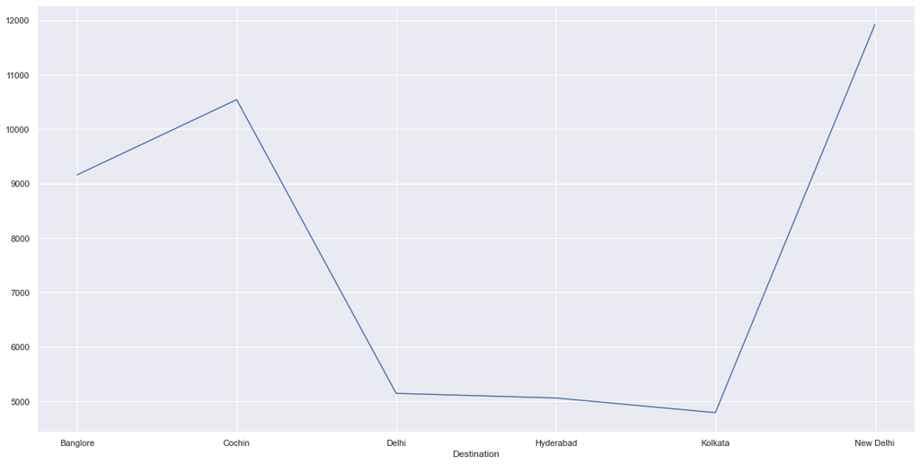

```python
df.groupby('Destination')['Price'].mean().plot(figsize=(20,10))
```

### here we can say that New Delhi Destination highest Price

### Destination is Nominal Categorical data we will perform OneHotEncoding

```python
Destination=df[['Destination']]

Destination=pd.get_dummies(Destination)
Destination.head()
```

|  | Destination_Banglore | Destination_Cochin | Destination_Delhi | Destination_Hyderabad | Destination_Kolkata | Destination_New Delhi |
| --- | --- | --- | --- | --- | --- | --- |
| 0 | 0 | 0 | 0 | 0 | 0 | 1 |
| 1 | 1 | 0 | 0 | 0 | 0 | 0 |
| 2 | 0 | 1 | 0 | 0 | 0 | 0 |
| 3 | 1 | 0 | 0 | 0 | 0 | 0 |
| 4 | 0 | 0 | 0 | 0 | 0 | 1 |

## check Route column

```python
df["Route"]
```

```
0                    BLR → DEL
1        CCU → IXR → BBI → BLR
2        DEL → LKO → BOM → COK
3              CCU → NAG → BLR
4              BLR → NAG → DEL
                 ...
10678                CCU → BLR
10679                CCU → BLR
10680                BLR → DEL
10681                BLR → DEL
10682    DEL → GOI → BOM → COK
Name: Route, Length: 10682, dtype: object
```

## Drop Route and Additional_Info columns because its unrelevant

```python
df.drop(["Route", "Additional_Info"], axis = 1, inplace = True)
```

## check Total_stops value counts

```python
df['Total_Stops'].value_counts()
```

```
1 stop      5625
non-stop    3491
2 stops     1520
3 stops       45
4 stops        1
Name: Total_Stops, dtype: int64
```

## Display Average price of all Total_Stops

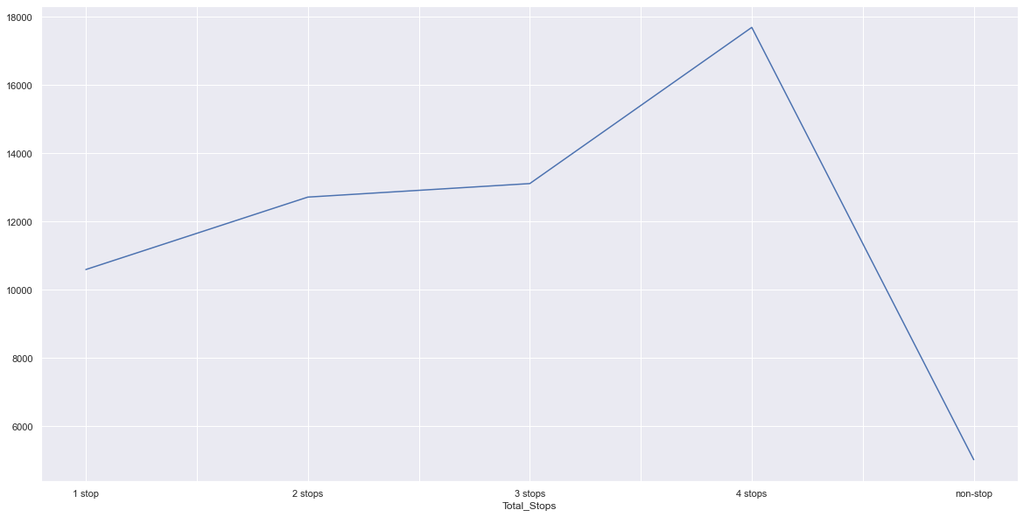

```python
df.groupby('Total_Stops')['Price'].mean().plot(figsize=(20,10))
```

### Hear we can sa that 4 stop highest price and non-stop flights lowest-priced

### Now replace categorical value in Total_stop with numeric value by manually

```python
df['Total_Stops']=df['Total_Stops'].replace({'non-stop':0,'1 stop':1,'2 stops':2,'3 stops':3,'4 stops':4})
df.head()
```

|  | Airline | Source | Destination | Total_Stops | Price | Day_of_Journey | Month_of_Journey | dep_hour | dep_min | Arri_hour | Arri_min |
| --- | --- | --- | --- | --- | --- | --- | --- | --- | --- | --- | --- |
| 0 | IndiGo | Banglore | New Delhi | 0 | 3897 | 24 | 3 | 22 | 20 | 1 | 10 |
| 1 | Air India | Kolkata | Banglore | 2 | 7662 | 1 | 5 | 5 | 50 | 13 | 15 |
| 2 | Jet Airways | Delhi | Cochin | 2 | 13882 | 9 | 6 | 9 | 25 | 4 | 25 |
| 3 | IndiGo | Kolkata | Banglore | 1 | 6218 | 12 | 5 | 18 | 5 | 23 | 30 |
| 4 | IndiGo | Banglore | New Delhi | 1 | 13302 | 1 | 3 | 16 | 50 | 21 | 35 |

## Now concatenate all dummy data which we created with our orignal dataset

```python
df=pd.concat([df,df_dur,Airline,Source,Destination], axis=1)
df.head()
```

|  | Airline | Source | Destination | Total_Stops | Price | Day_of_Journey | Month_of_Journey | dep_hour | dep_min | Arri_hour | Arri_min | Dur_hours | Dur_min | Air Asia | Air India | GoAir | IndiGo | Jet Airways | Jet Airways Business | Multiple carriers | Multiple carriers Premium economy | SpiceJet | Trujet | Vistara | Vistara Premium economy | Source_Banglore | Source_Chennai | Source_Delhi | Source_Kolkata | … |
| --- | --- | --- | --- | --- | --- | --- | --- | --- | --- | --- | --- | --- | --- | --- | --- | --- | --- | --- | --- | --- | --- | --- | --- | --- | --- | --- | --- | --- | --- | --- |
| 0 | IndiGo | Banglore | New Delhi | 0.0 | 3897.0 | 24.0 | 3.0 | 22.0 | 20.0 | 1.0 | 10.0 | 2 | 50 | 0.0 | 0.0 | 0.0 | 1.0 | 0.0 | 0.0 | 0.0 | 0.0 | 0.0 | 0.0 | 0.0 | 0.0 | 1.0 | 0.0 | 0.0 | 0.0 | … |
| 1 | Air India | Kolkata | Banglore | 2.0 | 7662.0 | 1.0 | 5.0 | 5.0 | 50.0 | 13.0 | 15.0 | 7 | 25 | 0.0 | 1.0 | 0.0 | 0.0 | 0.0 | 0.0 | 0.0 | 0.0 | 0.0 | 0.0 | 0.0 | 0.0 | 0.0 | 0.0 | 0.0 | 1.0 | … |
| 2 | Jet Airways | Delhi | Cochin | 2.0 | 13882.0 | 9.0 | 6.0 | 9.0 | 25.0 | 4.0 | 25.0 | 19 | 0 | 0.0 | 0.0 | 0.0 | 0.0 | 1.0 | 0.0 | 0.0 | 0.0 | 0.0 | 0.0 | 0.0 | 0.0 | 0.0 | 0.0 | 1.0 | 0.0 | … |
| 3 | IndiGo | Kolkata | Banglore | 1.0 | 6218.0 | 12.0 | 5.0 | 18.0 | 5.0 | 23.0 | 30.0 | 5 | 25 | 0.0 | 0.0 | 0.0 | 1.0 | 0.0 | 0.0 | 0.0 | 0.0 | 0.0 | 0.0 | 0.0 | 0.0 | 0.0 | 0.0 | 0.0 | 1.0 | … |
| 4 | IndiGo | Banglore | New Delhi | 1.0 | 13302.0 | 1.0 | 3.0 | 16.0 | 50.0 | 21.0 | 35.0 | 4 | 45 | 0.0 | 0.0 | 0.0 | 1.0 | 0.0 | 0.0 | 0.0 | 0.0 | 0.0 | 0.0 | 0.0 | 0.0 | 1.0 | 0.0 | 0.0 | 0.0 | … |

## Drop Categorical columns from dataset

```python
df.drop(['Airline','Source','Destination'], axis=1,inplace=True)
df.head()
```

|  | Total_Stops | Price | Day_of_Journey | Month_of_Journey | dep_hour | dep_min | Arri_hour | Arri_min | Dur_hours | Dur_min | Air Asia | Air India | GoAir | IndiGo | Jet Airways | Jet Airways Business | Multiple carriers | Multiple carriers Premium economy | SpiceJet | Trujet | Vistara | Vistara Premium economy | Source_Banglore | Source_Chennai | Source_Delhi | Source_Kolkata | Source_Mumbai | Destination_Banglore | Destination_Cochin | … |
| --- | --- | --- | --- | --- | --- | --- | --- | --- | --- | --- | --- | --- | --- | --- | --- | --- | --- | --- | --- | --- | --- | --- | --- | --- | --- | --- | --- | --- | --- | --- |
| 0 | 0.0 | 3897.0 | 24.0 | 3.0 | 22.0 | 20.0 | 1.0 | 10.0 | 2 | 50 | 0.0 | 0.0 | 0.0 | 1.0 | 0.0 | 0.0 | 0.0 | 0.0 | 0.0 | 0.0 | 0.0 | 0.0 | 1.0 | 0.0 | 0.0 | 0.0 | 0.0 | 0.0 | 0.0 | … |
| 1 | 2.0 | 7662.0 | 1.0 | 5.0 | 5.0 | 50.0 | 13.0 | 15.0 | 7 | 25 | 0.0 | 1.0 | 0.0 | 0.0 | 0.0 | 0.0 | 0.0 | 0.0 | 0.0 | 0.0 | 0.0 | 0.0 | 0.0 | 0.0 | 0.0 | 1.0 | 0.0 | 1.0 | 0.0 | … |
| 2 | 2.0 | 13882.0 | 9.0 | 6.0 | 9.0 | 25.0 | 4.0 | 25.0 | 19 | 0 | 0.0 | 0.0 | 0.0 | 0.0 | 1.0 | 0.0 | 0.0 | 0.0 | 0.0 | 0.0 | 0.0 | 0.0 | 0.0 | 0.0 | 1.0 | 0.0 | 0.0 | 0.0 | 1.0 | … |
| 3 | 1.0 | 6218.0 | 12.0 | 5.0 | 18.0 | 5.0 | 23.0 | 30.0 | 5 | 25 | 0.0 | 0.0 | 0.0 | 1.0 | 0.0 | 0.0 | 0.0 | 0.0 | 0.0 | 0.0 | 0.0 | 0.0 | 0.0 | 0.0 | 0.0 | 1.0 | 0.0 | 1.0 | 0.0 | … |
| 4 | 1.0 | 13302.0 | 1.0 | 3.0 | 16.0 | 50.0 | 21.0 | 35.0 | 4 | 45 | 0.0 | 0.0 | 0.0 | 1.0 | 0.0 | 0.0 | 0.0 | 0.0 | 0.0 | 0.0 | 0.0 | 0.0 | 1.0 | 0.0 | 0.0 | 0.0 | 0.0 | 0.0 | 0.0 | … |

## Finds correlation between Independent and dependent attributes

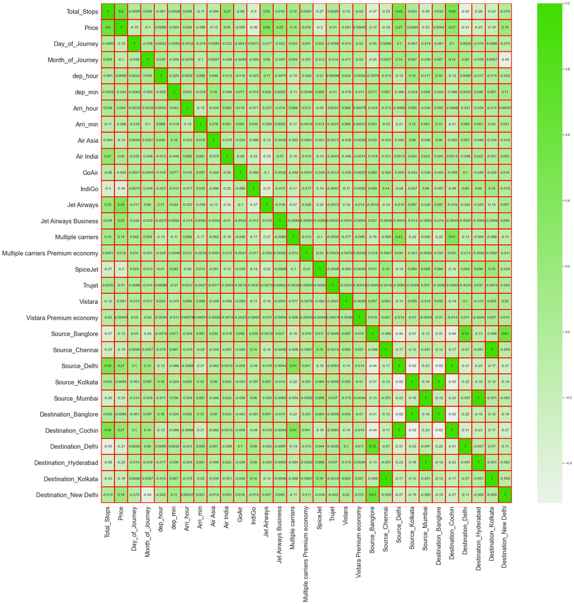

```python
plt.figure(figsize=(30,30))
plt.xticks(fontsize=20)
plt.yticks(fontsize=20)
cmap = sns.light_palette('#3fdd01',as_cmap=True)
sns.heatmap(df.corr(),annot=True, cmap=cmap, linewidths=2, linecolor='red')
```

## Find Nill Values

```python
df.isna().sum()
```

```
Total_Stops                          1
Price                                1
Day_of_Journey                       1
Month_of_Journey                     1
dep_hour                             1
dep_min                              1
Arri_hour                            1
Arri_min                             1
Dur_hours                            1
Dur_min                              1
Air Asia                             1
Air India                            1
GoAir                                1
IndiGo                               1
Jet Airways                          1
Jet Airways Business                 1
Multiple carriers                    1
Multiple carriers Premium economy    1
SpiceJet                             1
Trujet                               1
Vistara                              1
Vistara Premium economy              1
Source_Banglore                      1
Source_Chennai                       1
Source_Delhi                         1
Source_Kolkata                       1
Source_Mumbai                        1
Destination_Banglore                 1
Destination_Cochin                   1
Destination_Delhi                    1
Destination_Hyderabad                1
Destination_Kolkata                  1
Destination_New Delhi                1
dtype: int64
```

## Drop Null values

```python
df.dropna(inplace=True)
```

```python
df.shape
```

```
(10681, 33)
```

## Creat Features and Target

```python
x=df.drop('Price', axis=1)
y=df['Price']
```

## Feature selection

```python
from sklearn.feature_selection import chi2, SelectKBest, f_regression
```

```python
bestfeature=SelectKBest(score_func=f_regression)
fit=bestfeature.fit(x,y)
```

## print all features importances

```python
fit.pvalues_
```

```
array([0.00000000e+000, 1.67646495e-057, 6.55393901e-027, 4.80772491e-001,
       1.11728081e-002, 1.23791541e-002, 4.80874648e-019, 0.00000000e+000,
       3.44817589e-031, 2.22803561e-043, 1.95650762e-007, 6.56254155e-023,
       0.00000000e+000, 0.00000000e+000, 5.03389433e-156, 9.12824206e-048,
       6.81135368e-002, 8.87106435e-216, 2.83403812e-001, 3.55408419e-010,
       9.62662897e-001, 1.93318374e-034, 8.53159422e-078, 1.17380263e-178,
       3.31834077e-001, 4.44793976e-129, 3.31834077e-001, 1.17380263e-178,
       4.42840597e-242, 4.44793976e-129, 8.53159422e-078, 3.40712244e-087])
```

```python
best_feature=pd.Series(fit.scores_, index=x.columns)
best_feature
```

```
Total_Stops                          6130.185597
Day_of_Journey                        258.551159
Month_of_Journey                      115.993646
dep_hour                                0.497145
dep_min                                 6.439865
Arri_hour                               6.257866
Arri_min                               79.805986
Dur_hours                            2433.795605
Dur_min                               135.776019
Air Asia                              192.429502
Air India                              27.111235
GoAir                                  97.556106
IndiGo                               1600.788818
Jet Airways                          2237.183106
Jet Airways Business                  732.200093
Multiple carriers                     212.918128
Multiple carriers Premium economy       3.328581
SpiceJet                             1029.720904
Trujet                                  1.150810
Vistara                                39.418054
Vistara Premium economy                 0.002191
Source_Banglore                       150.846003
Source_Chennai                        354.373655
Source_Delhi                          843.974772
Source_Kolkata                          0.941813
Source_Mumbai                         600.563587
Destination_Banglore                    0.941813
Destination_Cochin                    843.974772
Destination_Delhi                    1163.157885
Destination_Hyderabad                 600.563587
Destination_Kolkata                   354.373655
Destination_New Delhi                 399.064667
dtype: float64
```

## plot graph of feature importances for better visualization

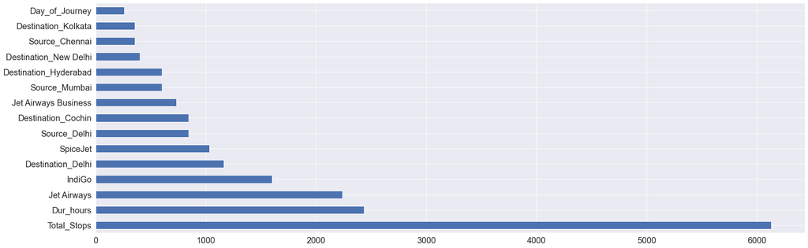

```python
plt.figure(figsize=(30,10))
plt.xticks(fontsize=20)
plt.yticks(fontsize=20)
best_feature.nlargest(15).plot(kind='barh')
```

```python
best_feature.reset_index()
```

|  | index | 0 |
| --- | --- | --- |
| 0 | Total_Stops | 6130.185597 |
| 1 | Day_of_Journey | 258.551159 |
| 2 | Month_of_Journey | 115.993646 |
| 3 | dep_hour | 0.497145 |
| 4 | dep_min | 6.439865 |
| 5 | Arri_hour | 6.257866 |
| 6 | Arri_min | 79.805986 |
| 7 | Dur_hours | 2433.795605 |
| 8 | Dur_min | 135.776019 |
| 9 | Air Asia | 192.429502 |
| 10 | Air India | 27.111235 |
| 11 | GoAir | 97.556106 |
| 12 | IndiGo | 1600.788818 |
| 13 | Jet Airways | 2237.183106 |
| 14 | Jet Airways Business | 732.200093 |
| 15 | Multiple carriers | 212.918128 |
| 16 | Multiple carriers Premium economy | 3.328581 |
| 17 | SpiceJet | 1029.720904 |
| 18 | Trujet | 1.150810 |
| 19 | Vistara | 39.418054 |
| 20 | Vistara Premium economy | 0.002191 |
| 21 | Source_Banglore | 150.846003 |
| 22 | Source_Chennai | 354.373655 |
| 23 | Source_Delhi | 843.974772 |
| 24 | Source_Kolkata | 0.941813 |
| 25 | Source_Mumbai | 600.563587 |
| 26 | Destination_Banglore | 0.941813 |
| 27 | Destination_Cochin | 843.974772 |
| 28 | Destination_Delhi | 1163.157885 |
| 29 | Destination_Hyderabad | 600.563587 |
| 30 | Destination_Kolkata | 354.373655 |
| 31 | Destination_New Delhi | 399.064667 |

## Select top 15 best feature

```python
l=pd.DataFrame(best_feature.nlargest(15))
```

```python
l.reset_index(inplace=True)
l
```

|  | index | 0 |
| --- | --- | --- |
| 0 | Total_Stops | 6130.185597 |
| 1 | Dur_hours | 2433.795605 |
| 2 | Jet Airways | 2237.183106 |
| 3 | IndiGo | 1600.788818 |
| 4 | Destination_Delhi | 1163.157885 |
| 5 | SpiceJet | 1029.720904 |
| 6 | Source_Delhi | 843.974772 |
| 7 | Destination_Cochin | 843.974772 |
| 8 | Jet Airways Business | 732.200093 |
| 9 | Source_Mumbai | 600.563587 |
| 10 | Destination_Hyderabad | 600.563587 |
| 11 | Destination_New Delhi | 399.064667 |
| 12 | Source_Chennai | 354.373655 |
| 13 | Destination_Kolkata | 354.373655 |
| 14 | Day_of_Journey | 258.551159 |

```python
l=list(l['index'])
l
```

```
['Total_Stops',
 'Dur_hours',
 'Jet Airways',
 'IndiGo',
 'Destination_Delhi',
 'SpiceJet',
 'Source_Delhi',
 'Destination_Cochin',
 'Jet Airways Business',
 'Source_Mumbai',
 'Destination_Hyderabad',
 'Destination_New Delhi',
 'Source_Chennai',
 'Destination_Kolkata',
 'Day_of_Journey']
```

```python
from sklearn.model_selection import train_test_split
```

```python
x_train, x_test, y_train, y_test = train_test_split(x,y,test_size=0.2,random_state=13)
```

## Applying All model

```python
from sklearn.linear_model import LinearRegression, Lasso, Ridge
from sklearn.tree import DecisionTreeRegressor
from sklearn.ensemble import RandomForestRegressor, GradientBoostingRegressor, AdaBoostRegressor
from sklearn.neighbors import KNeighborsRegressor
from sklearn.svm import SVR
from sklearn.naive_bayes import GaussianNB
from sklearn.discriminant_analysis import LinearDiscriminantAnalysis, QuadraticDiscriminantAnalysis
from xgboost import XGBRegressor
```

```python
models={'LinearRegression':LinearRegression(),
        'Lasso':Lasso(),
        'Ridge':Ridge(),
        'DecisionTree':DecisionTreeRegressor(),
        'RandomForest':RandomForestRegressor(),
        'KNN':KNeighborsRegressor(),
        'SVM':SVR(),
        'Naive Bayes':GaussianNB()
       }
```

```python
from sklearn.metrics import r2_score, mean_squared_error
```

```python
for name, model in models.items():
    model1=model.fit(x_train,y_train)
    y_pred = model1.predict(x_test)
    print(f'{name} Mean squared error:  {mean_squared_error(y_test,y_pred)}')
    print(f'{name} accuracy score: {model1.score(x_test,y_test)}\n')
```

```
LinearRegression Mean squared error:  7597868.10011913
LinearRegression accuracy score: 0.6368328205874056

Lasso Mean squared error:  7586259.963495047
Lasso accuracy score: 0.6373876728407553

Ridge Mean squared error:  7574757.49237035
Ridge accuracy score: 0.6379374744350427

DecisionTree Mean squared error:  5487979.790483024
DecisionTree accuracy score: 0.7376824505348032

RandomForest Mean squared error:  3134863.2034377675
RandomForest accuracy score: 0.8501580426989811

KNN Mean squared error:  9756163.147384183
KNN accuracy score: 0.5336694181267692

SVM Mean squared error:  21199334.51814689
SVM accuracy score: -0.01329773311789162

Naive Bayes Mean squared error:  9194693.963500233
Naive Bayes accuracy score: 0.24707533926064576
```

### Here we see RandomForestRegressor gives us best score so we can use RandomForestRegressor algorithm

```python
from sklearn.ensemble import RandomForestRegressor
reg_rf = RandomForestRegressor()
reg_rf.fit(x_train, y_train)
```

```
RandomForestRegressor()
```

```python
y_pred = reg_rf.predict(x_test)
```

```python
reg_rf.score(x_train, y_train)
```

```
0.9603928548492175
```

```python
reg_rf.score(x_test, y_test)
```

```
0.8486987375269007
```

## Save Model

```python
import pickle
telecom_model=open('telecon_model.sav','wb')
pickle.dump(reg_rf,telecom_model)
```

## Using LabelEncoding

```python
new_df=pd.concat([df,df_dur], axis=1)
new_df.head()
```

[output not shown]

```python
new_df.drop(['Additional_Info'], axis=1,inplace=True)
new_df.head()
```

[output not shown]

### LabelEncoding

```python
from sklearn.preprocessing import LabelEncoder
```

```python
lable=LabelEncoder()
```

```python
new_df[['Airline','Source','Destination','Route','Total_Stops']]=new_df[['Airline','Source','Destination','Route','Total_Stops']].apply(lable.fit_transform)
```

```python
new_df.head()
```

[output not shown]

```python
new_df.isna().sum()
```

```
Airline             0
Source              0
Destination         0
Route               0
Total_Stops         0
Price               1
Day_of_Journey      1
Month_of_Journey    1
dep_hour            1
dep_min             1
Arri_hour           1
Arri_min            1
Dur_hours           1
Dur_min             1
dtype: int64
```

```python
new_df.dropna(inplace=True)
```

```python
x=new_df.drop(['Price'], axis=1)
y=new_df['Price']
```

```python
from sklearn.model_selection import train_test_split
```

```python
x_train, x_test, y_train, y_test = train_test_split(x,y,test_size=0.2,random_state=8)
```

```python
for name, model in models.items():
    model1=model.fit(x_train,y_train)
    y_pred = model1.predict(x_test)
    print(f'{name} Mean squared error:  {mean_squared_error(y_test,y_pred)}')
    print(f'{name} accuracy score: {model1.score(x_test,y_test)}\n')
```

```
LinearRegression Mean squared error:  13561640.37102946
LinearRegression accuracy score: 0.3979752983064162

Lasso Mean squared error:  13562200.846992368
Lasso accuracy score: 0.39795041780780804

Ridge Mean squared error:  13561687.11788014
Ridge accuracy score: 0.39797322313275985

DecisionTree Mean squared error:  5989708.099568451
DecisionTree accuracy score: 0.7341064846714696

RandomForest Mean squared error:  3395343.6570920064
RandomForest accuracy score: 0.8492748151119973

KNN Mean squared error:  9102163.882564344
KNN accuracy score: 0.5959391824109441

SVM Mean squared error:  22206229.293122545
SVM accuracy score: 0.014227025626649459

Naive Bayes Mean squared error:  8985070.242863828
Naive Bayes accuracy score: 0.2980814225549836
```